# D206 Data Cleaning

## Performance Assessment

### A: Research Question

What are the primary predictors of customer churn?

Understanding the underlying causes of customer churn is important for any organization. By understanding what leads customers to terminate their contracts, an organization can create counter measures to reduce the churn rate and grow their customer base without having to invest as much money into acquiring new customers.

### B: Variable Description

| Variable | Type | Description | Example |
| --- | --- | --- | --- |
| CaseOrder | Qualitative | Placeholder to preserve order in the original file. | 1 |
| Customer_id | Qualitative | Unique ID for each customer. | K409198 |
| Interaction | Qualitative | Unique ID for customer interactions with company. | aa90260b-4141-4a24-8e36-b04ce1f4f77b |
| City | Qualitative | City listed on customer's billing address. | Point Baker |
| State | Qualitative | State listed on customer's billing address. | AK |
| County | Qualitative | County for customer's billing address. | San Diego |
| Zip | Qualitative | Zip code for customer's billing address. | 99927 |
| Lat | Quantitative | Latitude coordinates for customer's billing address. | 56.25100 |
| Lng | Quantitative | Longitudinal coordinates for customer's billing address. | -133.37571 |
| Population | Quantitative | Population within a one mile radius of customer's address. | 10446 |
| Area | Qualitative | Type of area the customer is located in. | Rural |
| TimeZone | Qualitative | Time zone based on customer's billing address. | America/Detroit |
| Job | Qualitative | Occupation of customer. | Solicitor |
| Children | Quantitative | Reported number of children in customer's household. | 1.0 |
| Age | Quantitative | Customer's age. | 27.0 |
| Education | Qualitative | Customer's education level. | Master's Degree |
| Employment | Qualitative | Customer's employment status. | Part Time |
| Income | Quantitative | Customer's annual income. | 28561.99 |
| Marital | Qualitative | Customer's marital status. | Divorced |
| Gender | Qualitative | Customer's gender. | Male |
| Churn | Qualitative | Did the customer end their contract in the last month? | Yes |
| Outage_sec_perweek | Quantitative | Weekly average of system outages in customer's area in seconds. | 12.014541 |
| Email | Quantitative | Number of emails sent to customer by company in the last year. | 10 |
| Contacts | Quantitative | Number of times technical support was contacted by customer. | 2 |
| Yearly_equip_failure | Quantitative | Number of times the customer experienced equipment failure in the last year. | 1 |
| Techie | Qualitative | Does the customer consider themselves tech savy? | No |
| Contract | Qualitative | Lenth of customer's contract. | One Year |
| Port_modem | Qualitative | Does the customer have a portable modem? | Yes |
| Tablet | Qualitative | Does the customer have a tablet device? | Yes |
| InternetService | Qualitative | Type of internet service the customer uses. | DSL |
| Phone | Qualitative | Does the customer have a phone service? | Yes |
| Multiple | Qualitative | Does the customer have multiple phone lines? | Yes |
| OnlineSecurity | Qualitative | Does the customer have an online security add-on? | No |
| OnlineBackup | Qualitative | Does the customer have an online backup add-on? | Yes |
| DeviceProtection | Qualitative | Does the customer have a device protection add-on? | Yes |
| TechSupport | Qualitative | Does the customer have a technical support add-on? | No |
| StreamingTV | Qualitative | Does the customer have a tv streaming service? | Yes |
| StreamingMovies | Qualitative | Does the customer have a movie streaming service? | No |
| PaperlessBilling | Qualitative | Does the customer use paperless billing? | Yes |
| PaymentMethod | Qualitative | Payment method used by customer. | Credit Card(automatic) |
| Tenure | Quantitative | Length of time the customer has been with the company in months. | 6.795513 |
| MonthlyCharge | Quantitative | Customer's average monthly billing. | 171.449762 |
| Bandwidth_GB_Year | Quantitative | Average amount of data used per year by the customer in gigabytes. | 904.536110 |
| Item1 | Qualitative | How important are timely responses to customer? | 5 |
| Item2 | Qualitative | How important are timely repairs to customer? | 4 |
| Item3 | Qualitative | How important are timely equipment replacements to customer? | 8 |
| Item4 | Qualitative | How important is service reliability to customer? | 1 |
| Item5 | Qualitative | How important are service options to customer? | 3 |
| Item6 | Qualitative | How important are respectful responses to questions to the customer? | 2 |
| Item7 | Qualitative | How important are courteous exchanges with customer service representatives to the customer? | 7 |
| Item8 | Qualitative | How important is evidence of active listening from customer service representatives to the customer? | 6 |

### C1: Plan for Assessing Data Quality

#### Duplicates:

To check for duplicates, I used the duplicated method with the value counts method to find and count the number of duplicates in the data set.

#### Missing Values:

To check for missing values, I used the isnull and sum methods to count the number of null values in each column.

#### Outliers:

To detect outliers, I generated a box plot for each quantitative column.

#### Categorical Variables:

I used the info, unique, describe, and value counts methods to assess the qualitative columns for value and data type issues.

### C2: Justification for Approach to Plan

#### Duplicates:

The duplicated method goes through each row in the data frame or column and compares it against all the previous rows to see if it is identical to any of them. If it isn't identical, it returns a False value, otherwise it will return a True value. The value counts method allows us to see how many times the duplicated method returned True and False. This tells us immediately how many duplicates we have.

#### Missing Values:

The isnull method goes through the data frame and returns a data frame containing True values where it encountered a null value. The sum method then counts the number of nulls in each column by summing the boolean values with True being 1 and False being 0. This gives us the number of null values in each column.

#### Outliers:

A boxplot is simple way of displaying our data with the median at the center, the first and third quartile on either side, and the minimum and maximum whiskers on the ends. Values that fall outside the whiskers are shown as dots and represent the outliers. It is a quick and easy way to identify outliers and roughly where those values fall.

#### Catergorical Variables:

The info method displays a range of information about each column including its data type. This allows us to quickly see columns whose data type may be incorrect. The unique method allows us to see the unique values within a column and can help identify typos and other value errors. The value counts method is similar to the unique method but also shows us how many times each value appears in the column. The describe method, when used on a numerical column, returns a range of values including the mean, min, and max values in a column. It can be used to identify value issues in numerical columns.

### C3: Programming Language and Libraries

#### Programming Language:

I chose to use Python for this project for its simple syntax, easy readability, and robust selection of libraries to extend it capabilities.

#### Libraries:

For this project, I used the pandas, numpy, matplotlib, seaborn, warnings, and sklearn libraries. The pandas library is the go to python library for working with data frames. It makes working with the data set very simple and straighforward. Numpy, which pandas is built on, allows us to run certain calculations more efficiently using arrays. Matplotlib and seaborn are very useful for generating graphs and other visuals. Sklearn was utilized for its capabilities in doing principle component analysis. The warning library was used to hide certain warning messages that were popping up but otherwise did not interfere with the code.

### C4: Code

```python
# import packages
import pandas as pd
import numpy as np
import matplotlib.pyplot as plt
%matplotlib inline
import seaborn as sns
```

```python
df = pd.read_csv('churn_raw_data.csv', index_col=0)
df.columns = df.columns.str.lower() # convert column names to all lowercase
```

```python
# create copy of dataframe for analysis and treatment
churn = df.copy()
```

```python
# detecting duplicates
print('Full Data Frame:\n', churn.duplicated().value_counts(), '\n')
print('Using only Customer ID:\n', churn['customer_id'].duplicated().value_counts(), '\n')
print('Using only Case Order:\n', churn['caseorder'].duplicated().value_counts(), '\n')
print('Using only Interaction:\n', churn['interaction'].duplicated().value_counts())
```

```
Full Data Frame:
 False    10000
Name: count, dtype: int64

Using only Customer ID:
 customer_id
False    10000
Name: count, dtype: int64

Using only Case Order:
 caseorder
False    10000
Name: count, dtype: int64

Using only Interaction:
 interaction
False    10000
Name: count, dtype: int64
```

```python
# check variable data types
churn.info()
```

```
<class 'pandas.core.frame.DataFrame'>
Index: 10000 entries, 1 to 10000
Data columns (total 51 columns):
 #   Column                Non-Null Count  Dtype
---  ------                --------------  -----
 0   caseorder             10000 non-null  int64
 1   customer_id           10000 non-null  object
 2   interaction           10000 non-null  object
 3   city                  10000 non-null  object
 4   state                 10000 non-null  object
 5   county                10000 non-null  object
 6   zip                   10000 non-null  int64
 7   lat                   10000 non-null  float64
 8   lng                   10000 non-null  float64
 9   population            10000 non-null  int64
```

[output cut: 43 more lines]

```python
# detecting missing values
churn.isnull().sum()
```

```
caseorder                  0
customer_id                0
interaction                0
city                       0
state                      0
county                     0
zip                        0
lat                        0
lng                        0
population                 0
area                       0
timezone                   0
job                        0
children                2495
age                     2475
education                  0
employment                 0
income                  2490
marital                    0
gender                     0
churn                      0
outage_sec_perweek         0
email                      0
contacts                   0
yearly_equip_failure       0
techie                  2477
contract                   0
port_modem                 0
tablet                     0
internetservice         2129
phone                   1026
multiple                   0
onlinesecurity             0
onlinebackup               0
deviceprotection           0
techsupport              991
streamingtv                0
streamingmovies            0
paperlessbilling           0
paymentmethod              0
tenure                   931
monthlycharge              0
bandwidth_gb_year       1021
item1                      0
item2                      0
item3                      0
item4                      0
item5                      0
item6                      0
item7                      0
item8                      0
dtype: int64
```

```python
# check values in city column
print(churn['city'].unique()) # won't print out all values, very long
```

```
['Point Baker' 'West Branch' 'Yamhill' ... 'Haubstadt' 'West Kill'
 'Clarkesville']
```

```python
# check values in state column
print(churn['state'].unique())
```

```
['AK' 'MI' 'OR' 'CA' 'TX' 'GA' 'TN' 'OK' 'FL' 'OH' 'PA' 'PR' 'IA' 'ME'
 'IL' 'WI' 'NC' 'AL' 'NM' 'VT' 'MD' 'NY' 'WA' 'CT' 'NJ' 'DC' 'ND' 'LA'
 'NE' 'WV' 'AZ' 'MO' 'WY' 'MT' 'VA' 'KY' 'MN' 'KS' 'MA' 'IN' 'SC' 'NH'
 'DE' 'MS' 'ID' 'AR' 'SD' 'CO' 'HI' 'UT' 'RI' 'NV']
```

```python
# check values in country column
print(churn['county'].unique()) # won't print out all values, very long
```

```
['Prince of Wales-Hyder' 'Ogemaw' 'Yamhill' ... 'Billings' 'Haralson'
 'Briscoe']
```

```python
# check zip column
churn['zip'].describe()
```

```
count    10000.000000
mean     49153.319600
std      27532.196108
min        601.000000
25%      26292.500000
50%      48869.500000
75%      71866.500000
max      99929.000000
Name: zip, dtype: float64
```

```python
# check area column
churn['area'].value_counts()
```

```
area
Suburban    3346
Urban       3327
Rural       3327
Name: count, dtype: int64
```

```python
# check timezone column
churn['timezone'].value_counts()
```

```
timezone
America/New_York                  4072
America/Chicago                   3672
America/Los_Angeles                887
America/Denver                     552
America/Detroit                    265
America/Indiana/Indianapolis       186
America/Phoenix                    104
America/Boise                       57
America/Anchorage                   55
America/Puerto_Rico                 40
Pacific/Honolulu                    35
America/Menominee                   16
America/Nome                        12
America/Kentucky/Louisville         10
America/Sitka                        8
America/Indiana/Vincennes            6
America/Indiana/Tell_City            6
America/Toronto                      5
America/Indiana/Petersburg           4
America/Juneau                       2
America/North_Dakota/New_Salem       2
America/Indiana/Knox                 1
America/Indiana/Winamac              1
America/Indiana/Marengo              1
America/Ojinaga                      1
Name: count, dtype: int64
```

```python
# check job column
churn['job'].value_counts()
```

```
job
Occupational psychologist               30
Comptroller                             28
Hospital pharmacist                     28
Horticultural therapist                 28
Ranger/warden                           27
                                        ..
Control and instrumentation engineer     6
Travel agency manager                    6
Accountant, chartered certified          6
Arboriculturist                          6
Toxicologist                             6
Name: count, Length: 639, dtype: int64
```

```python
# check education column
churn['education'].value_counts()
```

```
education
Regular High School Diploma                 2421
Bachelor's Degree                           1703
Some College, 1 or More Years, No Degree    1562
9th Grade to 12th Grade, No Diploma          870
Master's Degree                              764
Associate's Degree                           760
Some College, Less than 1 Year               652
Nursery School to 8th Grade                  449
GED or Alternative Credential                387
Professional School Degree                   198
No Schooling Completed                       118
Doctorate Degree                             116
Name: count, dtype: int64
```

```python
# check employment column
churn['employment'].value_counts()
```

```
employment
Full Time     5992
Part Time     1042
Retired       1011
Unemployed     991
Student        964
Name: count, dtype: int64
```

```python
# check marital column
churn['marital'].value_counts()
```

```
marital
Divorced         2092
Widowed          2027
Separated        2014
Never Married    1956
Married          1911
Name: count, dtype: int64
```

```python
# check gender column
churn['gender'].value_counts()
```

```
gender
Female                  5025
Male                    4744
Prefer not to answer     231
Name: count, dtype: int64
```

```python
# check churn column
churn['churn'].value_counts()
```

```
churn
No     7350
Yes    2650
Name: count, dtype: int64
```

```python
# check techie column
churn['techie'].value_counts()
```

```
techie
No     6266
Yes    1257
Name: count, dtype: int64
```

```python
# check contract column
churn['contract'].value_counts()
```

```
contract
Month-to-month    5456
Two Year          2442
One year          2102
Name: count, dtype: int64
```

```python
# check port modem column
churn['port_modem'].value_counts()
```

```
port_modem
No     5166
Yes    4834
Name: count, dtype: int64
```

```python
# check tablet column
churn['tablet'].value_counts()
```

```
tablet
No     7009
Yes    2991
Name: count, dtype: int64
```

```python
# check internet service column
churn['internetservice'].value_counts()
```

```
internetservice
Fiber Optic    4408
DSL            3463
Name: count, dtype: int64
```

```python
# check phone column
churn['phone'].value_counts()
```

```
phone
Yes    8128
No      846
Name: count, dtype: int64
```

```python
# check multiple column
churn['multiple'].value_counts()
```

```
multiple
No     5392
Yes    4608
Name: count, dtype: int64
```

```python
# check online security column
churn['onlinesecurity'].value_counts()
```

```
onlinesecurity
No     6424
Yes    3576
Name: count, dtype: int64
```

```python
# check online backup column
churn['onlinebackup'].value_counts()
```

```
onlinebackup
No     5494
Yes    4506
Name: count, dtype: int64
```

```python
# check device protection column
churn['deviceprotection'].value_counts()
```

```
deviceprotection
No     5614
Yes    4386
Name: count, dtype: int64
```

```python
# check tech support column
churn['techsupport'].value_counts()
```

```
techsupport
No     5635
Yes    3374
Name: count, dtype: int64
```

```python
# check streaming tv column
churn['streamingtv'].value_counts()
```

```
streamingtv
No     5071
Yes    4929
Name: count, dtype: int64
```

```python
# check streaming movies column
churn['streamingmovies'].value_counts()
```

```
streamingmovies
No     5110
Yes    4890
Name: count, dtype: int64
```

```python
# check paperless billing column
churn['paperlessbilling'].value_counts()
```

```
paperlessbilling
Yes    5882
No     4118
Name: count, dtype: int64
```

```python
# check payment method column
churn['paymentmethod'].value_counts()
```

```
paymentmethod
Electronic Check            3398
Mailed Check                2290
Bank Transfer(automatic)    2229
Credit Card (automatic)     2083
Name: count, dtype: int64
```

```python
# check item1 column
churn['item1'].value_counts()
```

```
item1
3    3448
4    3358
2    1393
5    1359
1     224
6     199
7      19
Name: count, dtype: int64
```

```python
# check item2
churn['item2'].value_counts()
```

```
item2
3    3415
4    3412
5    1368
2    1360
1     217
6     215
7      13
Name: count, dtype: int64
```

```python
# check item3
churn['item3'].value_counts()
```

```
item3
3    3435
4    3410
2    1424
5    1313
6     203
1     202
7      12
8       1
Name: count, dtype: int64
```

```python
# check item4
churn['item4'].value_counts()
```

```
item4
4    3452
3    3430
2    1350
5    1335
1     221
6     203
7       9
Name: count, dtype: int64
```

```python
# check item5
churn['item5'].value_counts()
```

```
item5
3    3462
4    3417
2    1378
5    1321
1     206
6     204
7      12
Name: count, dtype: int64
```

```python
# check item6
churn['item6'].value_counts()
```

```
item6
3    3445
4    3333
2    1427
5    1382
6     210
1     190
7      12
8       1
Name: count, dtype: int64
```

```python
# check item7
churn['item7'].value_counts()
```

```
item7
4    3456
3    3446
5    1335
2    1309
6     224
1     219
7      11
Name: count, dtype: int64
```

```python
# check item8
churn['item8'].value_counts()
```

```
item8
3    3461
4    3400
2    1378
5    1335
1     206
6     205
7      14
8       1
Name: count, dtype: int64
```

```python
# create a new dataframe using only quantitative columns
churn_num = churn[['population','children','age','income','outage_sec_perweek',
                  'email','contacts','yearly_equip_failure','tenure',
                   'monthlycharge','bandwidth_gb_year']]
# save the number of columns to churn_num_col
churn_num_col  = churn_num.shape[1]
```

```python
# remove future warning messages [In-Text Citation: (Henley, 2023)]
import warnings
warnings.simplefilter(action='ignore', category=FutureWarning)
```

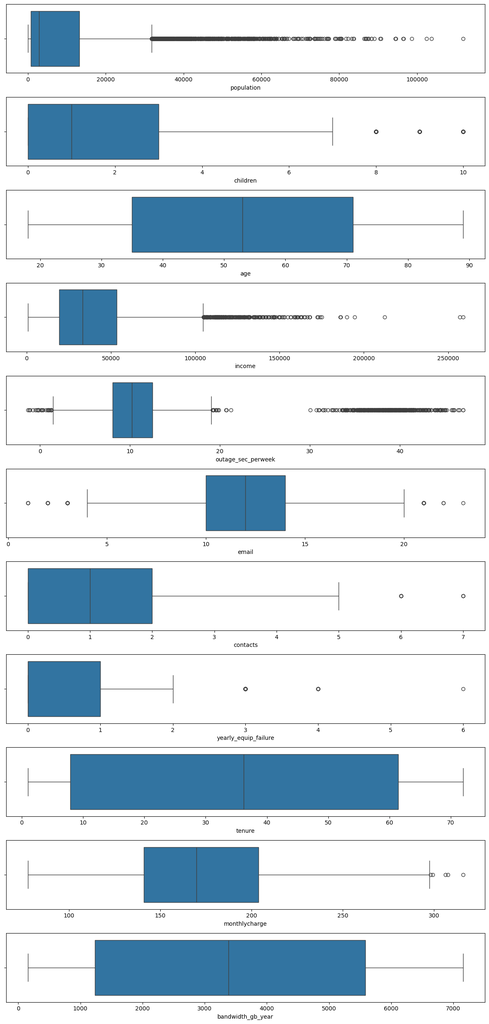

```python
# create boxplots for each quantitative column to detect outliers
plt.figure(figsize=(12,25))

for i in range(1, churn_num_col+1):
    plt.subplot(churn_num_col, 1, i)
    sns.boxplot(x=churn_num.columns[i-1], data=churn_num)

plt.tight_layout()
plt.show()
```

```python
# check number of outliers for each column showing outliers on the boxplot
pop_out = churn['population'] > 30000
children_out = churn['children'] > 7
income_out = churn['income'] > 110000
outage_out_lower = churn['outage_sec_perweek'] < 2
outage_out_upper = churn['outage_sec_perweek'] > 18
email_out_lower = churn['email'] < 4
email_out_upper = churn['email'] > 20
contacts_out = churn['contacts'] > 5
equip_fail_out = churn['yearly_equip_failure'] > 2
charge_out = churn['monthlycharge'] > 295

# print out the number of outliers
print('Number of population outliers:', pop_out.sum(), '\n')
print('Number of children outliers:', children_out.sum(), '\n')
print('Number of income outliers:', income_out.sum(), '\n')
print('Number of outage_sec_perweek low end outliers:',
      outage_out_lower.sum(), '\n')
print('Number of outage_sec_perweek upper end outliers:',
      outage_out_upper.sum(), '\n')
print('Number of email lower end outliers:', email_out_lower.sum(), '\n')
print('Number of email upper end outliers:', email_out_upper.sum(), '\n')
print('Number of contacts outliers:', contacts_out.sum(), '\n')
print('Number of yearly_equip_failure outliers:', equip_fail_out.sum(), '\n')
print('Number of monthly charge outliers:', charge_out.sum())
```

```
Number of population outliers: 1043

Number of children outliers: 302

Number of income outliers: 211

Number of outage_sec_perweek low end outliers: 44

Number of outage_sec_perweek upper end outliers: 555

Number of email lower end outliers: 23

Number of email upper end outliers: 15

Number of contacts outliers: 8

Number of yearly_equip_failure outliers: 94

Number of monthly charge outliers: 7
```

### D1: Findings

#### Duplicates:

No duplicate rows were found in the data set and the case order, customer id, and interaction columns all contained fully unique values.

#### Missing Values:

There are nine columns with missing values. The children, age, income, and techie columns are missing around two thousand five hundred values. The internetservice column is missing around two thousand one hundred values. The phone, techsupport, tenure, and bandwidth_gb_year columns are missing around one thousand values.

#### Outliers:

The population, children, income, outage_sec_perweek, email, contacts, yearly_equip_failure, and monthly_charge columns all show outliers on their boxplots. The population column has 1043 outliers. The children column has 302 outliers. The income columns has 211 outliers. The outage_sec_perweek has 44 outliers on the low end and 555 outliers on the high end. The email column has 23 outliers on the low end and 15 outliers on the high end. The contacts column has 8 outliers. The yearly_equip_failure column has 94 outliers. The monthly charge column has 7 outliers.

#### Categorical Variable

The time zone column is written in a region/city format that can be simplified to reduce the number of categories.

#### Variable Type:

The zip column is listed as type integer. However, a zip code is a fixed qualitative value. Children and age are listed as floats when they should be whole numbers.

### D2: Explanation for Mitigation Methods

#### Duplicates:

No duplicates were found in the data set.

#### Missing Values:

There are two main ways to deal with missing values. You can either delete the rows or columns containing them or use known data to impute a value to replace it. The problem with deletion is that you risk losing too much data and making your data set too small. The problem with imputation is that you risk skewing your data. To minimize both of these risks, I took the following actions. First, I looked the number of null values in each row and dropped rows containing four or more missing values. This eliminated around six percent of the rows in the data set. This allowed me to retain the majority of my data while significantly reducing the number values to be imputed. I then created histograms for the numerical columns to see how the values were distributed and determine how to impute the missing values. For normal/uniform distributions, I used the mean to impute the missing values. For skewed/bimodal distributions, I used the median to impute the missing values. For categorical columns, I used the mode to impute the missing values. Using the mean, median, and mode to impute the missing data allows us to replace the null values without changing the distribution of the data. The one exception to this is the internet service column. The data dictionary shows that the internet service column should contain the values 'Fiber Optic', 'DSL' or 'None'. However, when looking at the value counts for the column only 'Fiber Optic' and 'DSL' appear. Assuming the 'None' values were incorrectly read as null when importing the file, I replaced these null values with 'None'.

#### Outliers:

For the majority of the columns with outliers, I chose to take no action. The outliers in these columns did not fall outside what could be considered possible. Treating these values could potentially rob us of important insights into the data. For the population column, there are a significant number of outliers on the high end. However, it is possible that these are simply customers who live in more densely populated cities. To confirm this I would need to compare the population data and the city columns against another data source for population, but this falls outside the scope of this project. The income column shows customers with higher incomes as outliers, but they do not appear beyond what you could expect someone to earn in a year. The outage_sec_perweek column shows a large cluster of outliers who experience significantly more outage time than normal. This could be indicative of a serious issue the company needs to address and should be left alone. The email column shows that there are some customers who recieve more and fewer emails than normal, but the values do not exceed the minimums and maximums by an extreme amount. The contacts column shows a few customers who contact support more than is normal but not by a significantly larger amount and it is reasonably to assume that some customers may need more help than others. The yearly_equip_failure column shows some customers experiencing more equipment failure than usual, but these values may represent serious equipment quality issues and should not be removed without further investigation. Finally, the monthly charge column shows a small number of customers with slightly higher bills, but they do not exceed the maximum enough to warrant treatment.

The only column I chose to treat was the children column. When looking at the ages of those with more than seven children, a significant number of people under the age of 26 appeared. Assuming that they had one child a year, most of these individuals would have started having children as young as ten years old. I decided to replace these values using the median number of children for people under the age of 26. The median was used to in order to preserve the statistical distribution of the data. The other outliers for the children column weren't outside what could be considered possible and were not changed.

#### Categorical Variable:

I simplified the time zone column to reduce the number of categories down to seven. I did this by creating a dictionary with the old values as keys and the new values as the entry for each key. I then mapped the dictionary to the column and assigned it back to itself.

#### Variable Type:

I used the astype and zfill methods to convert the zip column to a string and add zeros to the front of the zip codes that would have lost their zeros when they were converted to integers.

I used the astype method again to convert the children and age columns from floats to integers.

### D3: Summary of Outcome

The null values were treated either through deletion or imputation. The histograms of the imputed columns do have spikes from the imputed values but the distribution and statistical distribution remain similar to before imputation (see D4 for visuals).

While some outliers do remain for the children column, the values are reasonably possible and will not be treated to maintain the integrity of the data.

### D4: Code for Mitigation

```python
# identify rows with many null values and create new column for those values
churn['null_count'] = churn.isnull().sum(axis=1)
print(churn['null_count'].value_counts())
```

```
null_count
1    3293
2    3023
0    1684
3    1431
4     458
5      95
6      16
Name: count, dtype: int64
```

```python
# drop rows with with more than four null values
churn.drop(churn[churn['null_count']>=4].index, inplace=True)
# drop null count column
churn.drop(columns=['null_count'], inplace=True)
```

```python
# impute categorical variables using the mode
churn['techie'].fillna(churn['techie'].mode()[0], inplace=True)
churn['phone'].fillna(churn['phone'].mode()[0], inplace=True)
churn['techsupport'].fillna(churn['techsupport'].mode()[0], inplace=True)
```

```python
# impute internet service column replacing null with 'None'
churn.loc[churn['internetservice'].isnull(), 'internetservice'] = 'None'
```

```python
print(churn['internetservice'].unique())
```

```
['Fiber Optic' 'DSL' 'None']
```

```
          children          age         income       tenure  bandwidth_gb_year
count  7264.000000  7291.000000    7286.000000  8677.000000        8597.000000
mean      2.095127    53.331093   39922.409893    34.419733        3393.691558
std       2.154991    20.747025   28349.715157    26.426769        2186.430288
min       0.000000    18.000000     901.210000     1.000259         155.506715
25%       0.000000    35.000000   19260.270000     7.896371        1234.244324
50%       1.000000    53.000000   33131.300000    30.769802        3277.280000
75%       3.000000    71.000000   53465.385000    61.373650        5583.510000
max      10.000000    89.000000  258900.700000    71.999280        7158.982000
```

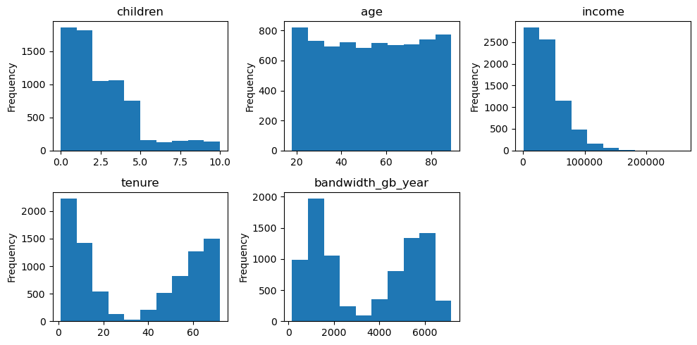

```python
# create new data fram for numerical columns with missing values
churn_num_missing = churn[['children','age','income',
                           'tenure','bandwidth_gb_year']]

print(churn_num_missing.describe(), '\n')
# generate histograms to check distribution type for each column
plt.figure(figsize=(10,5))

i = 1
for col in churn_num_missing.columns:
    plt.subplot(2, 3, i)
    churn[col].plot(kind='hist')
    plt.title(col)
    i += 1
plt.tight_layout()
plt.show()
```

```python
# impute bimodal and right skewed distributions with median
churn['children'].fillna(churn['children'].median(), inplace=True)
churn['income'].fillna(churn['income'].median(), inplace=True)
churn['tenure'].fillna(churn['tenure'].median(), inplace=True)
churn['bandwidth_gb_year'].fillna(churn['bandwidth_gb_year'].median(),
                                  inplace=True)
```

```python
# impute uniform distribution with mean
churn['age'].fillna(churn['age'].mean(), inplace=True)
```

```
          children          age         income       tenure  bandwidth_gb_year
count  9431.000000  9431.000000    9431.000000  9431.000000        9431.000000
mean      1.843495    53.331093   38377.830239    34.127925        3383.397078
std       1.946555    18.241635   25079.780651    25.367574        2087.768915
min       0.000000    18.000000     901.210000     1.000259         155.506715
25%       1.000000    41.000000   23289.220000     8.605155        1298.733009
50%       1.000000    53.331093   33131.300000    30.769802        3277.280000
75%       3.000000    66.000000   46361.460000    60.293075        5476.216000
max      10.000000    89.000000  258900.700000    71.999280        7158.982000
```

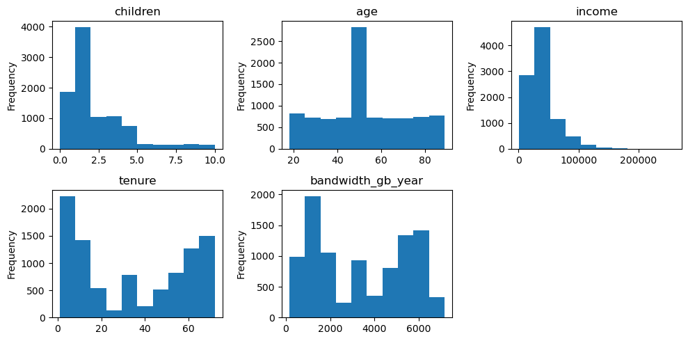

```python
# check values for columns using describe()
print(churn[['children','age','income',
             'tenure','bandwidth_gb_year']].describe(), '\n')

# replot and check distributions post imputation
plt.figure(figsize=(10,5))

i = 1
for col in churn_num_missing.columns:
    plt.subplot(2, 3, i)
    churn[col].plot(kind='hist')
    plt.title(col)
    i += 1
plt.tight_layout()
plt.show()
```

```python
# check for any remaining null values
churn.isnull().sum()
```

```
caseorder               0
customer_id             0
interaction             0
city                    0
state                   0
county                  0
zip                     0
lat                     0
lng                     0
population              0
area                    0
timezone                0
job                     0
children                0
age                     0
education               0
employment              0
income                  0
marital                 0
gender                  0
churn                   0
outage_sec_perweek      0
email                   0
contacts                0
yearly_equip_failure    0
techie                  0
contract                0
port_modem              0
tablet                  0
internetservice         0
phone                   0
multiple                0
onlinesecurity          0
onlinebackup            0
deviceprotection        0
techsupport             0
streamingtv             0
streamingmovies         0
paperlessbilling        0
paymentmethod           0
tenure                  0
monthlycharge           0
bandwidth_gb_year       0
item1                   0
item2                   0
item3                   0
item4                   0
item5                   0
item6                   0
item7                   0
item8                   0
dtype: int64
```

```python
# simplify time zone column
timezone_dict = {'America/New_York':'America/Eastern',
                'America/Chicago':'America/Central',
                'America/Los_Angeles':'America/Pacific',
                'America/Denver':'America/Mountain',
                'America/Detroit':'America/Eastern',
                'America/Indiana/Indianapolis':'America/Eastern',
                'America/Phoenix':'America/Mountain',
                'America/Boise':'America/Mountain',
                'America/Anchorage':'America/Alaska',
                'America/Puerto_Rico':'America/Atlantic',
                'Pacific/Honolulu':'Pacific/Hawaii-Aleutian',
                'America/Menominee':'America/Central',
                'America/Nome':'America/Alaska',
                'America/Kentucky/Louisville':'America/Eastern',
                'America/Sitka':'America/Alaska',
                'America/Indiana/Vincennes':'America/Eastern',
                'America/Indiana/Tell_City':'America/Central',
                'America/Toronto':'America/Eastern',
                'America/Indiana/Petersburg':'America/Eastern',
                'America/Juneau':'America/Alaska',
                'America/North_Dakota/New_Salem':'America/Central',
                'America/Indiana/Knox':'America/Central',
                'America/Indiana/Winamac':'America/Eastern',
                'America/Indiana/Marengo':'America/Eastern',
                'America/Ojinaga':'America/Central'}

churn['timezone'] = churn['timezone'].map(timezone_dict)
churn['timezone'].value_counts()
```

```
timezone
America/Eastern            4294
America/Central            3494
America/Pacific             838
America/Mountain            664
America/Alaska               73
America/Atlantic             36
Pacific/Hawaii-Aleutian      32
Name: count, dtype: int64
```

```python
# fix variable types
churn['zip'] = churn['zip'].astype('string').str.zfill(5)
churn['children'] = churn['children'].astype('int64')
churn['age'] = churn['age'].astype('int64')

print('Zip', churn['zip'].dtype, '\nChildren', churn['children'].dtype,
     '\nAge', churn['age'].dtype)
```

```
Zip string
Children int64
Age int64
```

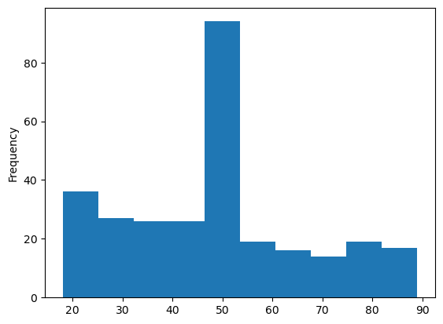

```python
# create new data frame containing only outliers for children
child_7plus = churn[churn['children'] > 7]

# plot a histogram of the ages of customers with more than seven children
child_7plus['age'].plot(kind='hist')
```

```python
# look at those under 30 with many children
child_7plus.loc[child_7plus['age']<30, 'age'].value_counts()
```

```
age
18    7
29    6
23    5
19    5
24    5
22    5
25    5
26    4
20    3
21    1
27    1
28    1
Name: count, dtype: int64
```

```python
# change number of children for those under 26 to median for that age group
churn.loc[(churn['children']>7)&(churn['age']<26),
          'children'] = churn.loc[churn['age']<26, 'children'].median()
```

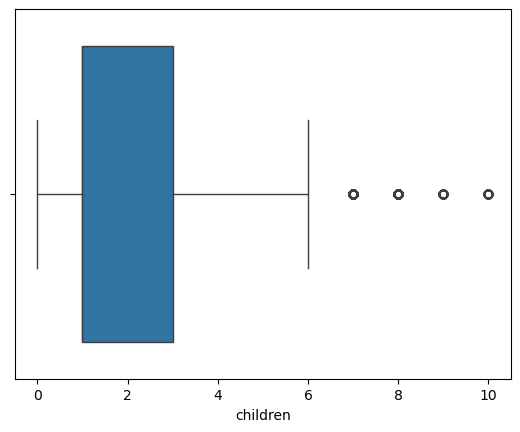

```python
# remake boxplot for children
sns.boxplot(x='children', data=churn)
```

### D5: Copy of Cleaned Data Set

See attached file.

```python
# code to export cleaned data
#commented out to prevent multiple copies being made
#churn.to_csv(r'C:\Users\caleb\Documents\WGU\D206\churn_clean_jantsch.csv')
```

### D6: Limitations of Process

#### Missing Values:

As discussed before, deleting rows can reduce our data set too much and lose valuable information. Imputation has the risk of distorting our data and reducing the accuracy of insights into the data.

While the isnull and sum method of detecting missing values is simple and useful, it can not account for missing values that were not found when using read csv to import the file. For example, if missing values were represented with a 0 or a period, they would be read into the data frame as such and would be harder to detect. It also cannot tell us if a value was wrongly made into a null. For example, the internetservice column used 'None' to represent customers that didn't have internet and it was wrongly converted to null when imported.

#### Outliers:

When treating outliers through imputation, we risk distorting our data and losing valuable insights into the data. It can also shift the data and create more outliers when looking at the data after imputation. This can create the temptation to impute the data again and further distort the information.

Retaining outliers can preserve our data set, but it can also decrease normality when utilizing statistical methods.

Boxplots allow us to quickly identify the presence of outliers within out data, but it can be difficult to determine where exactly the whiskers are on the x-axis. This can lead to treating values that were in fact not outliers if we incorrectly guess the min and max for the whiskers.

### D7: Affects of Limitations

It is possible that the data has become overly distorted from the imputation techniques used to fill the null values. This would reduce the accuracy of the analysis using the cleaned data. For example, distortions in the data could result in a variable appearing as a more important predictor of churn than it actually is and lead to the organization pursuing a course of action off of a false insight.

### E1: Principle Components

#### Variables used for PCA

1. population
2. children
3. age
4. income
5. outage_sec_perweek
6. email
7. contacts
8. yearly_equip_failure
9. tenure
10. monthlycharge
11. bandwidth_gb_year

```python
# import PCA from sklean
from sklearn.decomposition import PCA
```

```python
# create a dataframe with only quantitative variables
churn_quant = churn[['population','children','age','income','outage_sec_perweek',
                  'email','contacts','yearly_equip_failure','tenure',
                  'monthlycharge','bandwidth_gb_year']]
```

```python
# normalize data
churn_normal = (churn_quant - churn_quant.mean())/churn_quant.std()
```

```python
# set up PCA and designate number of components
pca = PCA(n_components=churn_quant.shape[1])
# fit to normalized data
pca.fit(churn_normal)
# transform data
churn_pca = pd.DataFrame(pca.transform(churn_normal),
                        columns=['PC1','PC2','PC3','PC4','PC5','PC6',
                                'PC7','PC8','PC9','PC10','PC11'])
```

```python
# PCA Loadings
loadings = pd.DataFrame(pca.components_.T,
                       columns=['PC1','PC2','PC3','PC4','PC5','PC6',
                                'PC7','PC8','PC9','PC10','PC11'],
                       index=churn_quant.columns)
print(loadings)
```

```
                           PC1       PC2       PC3       PC4       PC5  \
population            0.001315 -0.046507 -0.406566 -0.215269  0.304231
children              0.002689 -0.034119  0.497988  0.095748  0.340261
age                  -0.011234 -0.038043 -0.048849  0.743491  0.324659
income                0.003348 -0.011557  0.322188  0.171536 -0.428502
outage_sec_perweek    0.023559  0.704304  0.052000 -0.024473  0.009616
email                -0.026126  0.068072 -0.460916 -0.045743  0.398477
contacts              0.001721  0.013590 -0.348326  0.591159 -0.272495
yearly_equip_failure  0.014673  0.032717  0.378296  0.087568  0.518713
tenure                0.704823 -0.056637 -0.022010  0.010844  0.009032
monthlycharge         0.045496  0.699886 -0.020366  0.047885 -0.019256
bandwidth_gb_year     0.706790 -0.010578 -0.005957 -0.006987  0.001866

                           PC6       PC7       PC8       PC9      PC10  \
population           -0.192556  0.671613 -0.264977  0.367304 -0.019349
children             -0.453862 -0.252122  0.068286  0.592421 -0.020001
age                  -0.116076  0.004491 -0.472315 -0.295694  0.115298
income               -0.530484  0.524633  0.229119 -0.264732 -0.061485
outage_sec_perweek   -0.002042  0.081362  0.048455  0.046292  0.699206
email                -0.433154 -0.210391  0.538042 -0.314328 -0.033760
contacts              0.200936  0.059742  0.418356  0.484603 -0.030842
yearly_equip_failure  0.482391  0.392210  0.394889 -0.141619 -0.127872
tenure               -0.008464 -0.006124  0.004745 -0.024200  0.038265
monthlycharge        -0.033140 -0.040352 -0.163360  0.012167 -0.687876
bandwidth_gb_year    -0.013120 -0.012775  0.006481  0.005564 -0.013469

                          PC11
population           -0.000634
children             -0.017606
age                   0.023526
income                0.000468
outage_sec_perweek    0.001101
email                 0.006809
contacts             -0.001319
yearly_equip_failure -0.000397
tenure               -0.705090
monthlycharge        -0.047714
bandwidth_gb_year     0.706865
```

### E2: Explanation for Principle Component Selection

Using the Kaiser rule, where only components with an eigenvalue greater than or equal to one are used (Middleton, n.d.). I will retain PC1 through PC5. PC1 is the most important with the highest eigenvalue. PC2, PC3, PC4, and PC5 are the next most important values with the eigenvalue of each decreasing compared to the previous one.

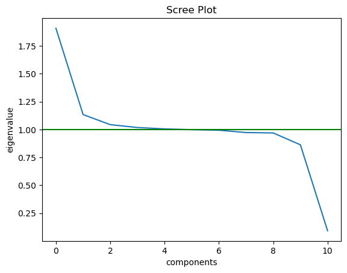

```python
# generate scree plot
cov_matrix = np.dot(churn_normal.T, churn_normal)/churn_quant.shape[0]
eigen = [np.dot(eigenvector.T,
                np.dot(cov_matrix, eigenvector)) for eigenvector in pca.components_]

plt.plot(eigen)
plt.title('Scree Plot')
plt.xlabel('components')
plt.ylabel('eigenvalue')
plt.axhline(y=1, color='green')
plt.show()
```

```python
# print out eigenvalues
print('Eigenvalues:', eigen)
```

```
Eigenvalues: [1.9077925803954334, 1.1340034786693882, 1.0438568541097137, 1.0179597527635338, 1.0056968228108785, 0.9984751708552997, 0.9936646112664276, 0.9730445658158372, 0.9692554456461143, 0.862874683056522, 0.09220966837177734]
```

### E3: Benefits of PCA

PCA allows us reduce the number of variables used in machine learning and thus use precious computing resources more efficiently at a minimal cost to accuracy. It also produces independent uncorrelated variables and reduces noise in the data (Bigabid, n.d.).

### F: Panopto Video

https://wgu.hosted.panopto.com/Panopto/Pages/Viewer.aspx?id=bd911899-40be-4212-baca-b0b3011165c1

### G: Code Sources

Hanley, P. (2023, July 10). *Ignoring FutureWarnings in Python pandas*. Stack Overflow. https://stackoverflow.com/questions/67797816/ignoring-futurewarnings-in-python-pandas

### H: Text Sources

Bigabid. (n.d.). *PCA: What, How, and Why*. Bigabid. https://www.bigabid.com/what-is-pca-and-how-can-i-use-it/

Middleton, K. (n.d.). *D206 - Getting Starting with D206 | PCA* [Video]. https://wgu.hosted.panopto.com/Panopto/Pages/Viewer.aspx?id=3bcc452f-fa35-43be-b69f-b05901356f95